# Visual detection of cryptic displays in jumping spiders

## Massimo De Agro’ (1), Francesca Lo Bello (1), Peter Neri (2, 3), Giorgio Vallortigara (1)

#### 1 - Center for Mind/Brain Sciences, University of Trento, Italy

#### 0.0.0.1 2 - Italian Institute of Technology, Genoa, Italy

#### 0.0.0.2 3 - Laboratoire des Systèmes Perceptifs (UMR8248), École normale supérieure, PSL Research University, Paris, France

#### Corresponding Author: Massimo De Agrò massimo.deagro@unitn.it

This document contains the statistical analysis output for the manuscript. We also provide the entire raw data on which this analysis is based. Note that much of the analysis is divided into sections using tabs, found at the start of the sections. Click on the section you wish to inspect, and scroll down for the full analysis.

In this experiment, we tested the ability of jumping spiders to perceive moving stimuli. The animals were placed on an omnidirectional treadmill, looking at a computer monitor. Here, we presented on the left or right side of the animal various stimuli, and registered the pivot reaction. In a second experiment, we added various control stimuli to ensure that the observed reaction for second order motion was indeed due to the perceived object, rather than any luminance change. In a third experiment, we tested whether the effect was maintained also for PLE, as in the first experiment the stimuli were only visible to ALE.

# 1 Prepare environment

## 1.1 loading packages

```r
library(data.table) #To deal with big datasets
library(glmmTMB)
library(emmeans)
library(car)
library(DHARMa)
```

```r
library(ggplot2)
set.seed(12345)
```

## 1.2 loading files

experiments 1 and 2 are in the same dataset. The two experiments are identical, but some of the control stimuli are different. Experiment 1 was done in April, Experiment 2 in May.

```r
data <- fread(paste0(basepath, 'SI2_data_exp1_2.csv'))
data$date <- as.factor(data$date)
data$subjID <- as.factor(data$subjID)
data$subjSex <- as.factor(data$subjSex)
data$treatment <- as.factor(data$treatment)
data$stimn <- as.numeric(data$stimn)
data$trialn <- as.factor(data$trialn)
data$noisesize <- as.factor(data$noisesize)
data$stimuli_angle_pos <- as.factor(data$stimuli_angle_pos)
data$stimuli_angle_size <- as.factor(data$stimuli_angle_size)

data$side <- as.factor(data$side)
data$stim_type <- set_stim(data$stim_type)
data$stim_type <- as.factor(data$stim_type)
data$speed <- as.factor(data$speed)

data$turnside <- as.factor(data$turnside)
```

Now, splitting data into the two separate experiments

```r
levels(data$date)
```

```
##  [1] "2024-04-09" "2024-04-11" "2024-04-16" "2024-04-17" "2024-04-18"
##  [6] "2024-04-19" "2024-05-02" "2024-05-03" "2024-05-07" "2024-05-09"
```

```r
exp1 <- subset(data,
        data$date=="2024-04-09" |
        data$date=="2024-04-11" |
        data$date=="2024-04-16" |
        data$date=="2024-04-17" |
        data$date=="2024-04-18" |
        data$date=="2024-04-19" )

exp2 <- subset(data,
        data$date=="2024-05-02" |
        data$date=="2024-05-03" |
        data$date=="2024-05-07" |
        data$date=="2024-05-09" )
```

Now exp 3

```r
exp3 <- fread(paste0(basepath, 'SI2_data_exp3.csv'))
exp3$date <- as.factor(exp3$date)
exp3$subjID <- as.factor(exp3$subjID)
exp3$subjSex <- as.factor(exp3$subjSex)
exp3$treatment <- as.factor(exp3$treatment)
exp3$stimn <- as.numeric(exp3$stimn)
exp3$trialn <- as.factor(exp3$trialn)
exp3$noisesize <- as.factor(exp3$noisesize)

exp3$side <- as.factor(exp3$side)
exp3$stim_type <- set_stim(exp3$stim_type)
exp3$stim_type <- as.factor(exp3$stim_type)

exp3$turnside <- as.factor(exp3$turnside)
exp3$eye<- as.factor(exp3$eye)
exp3$angle<- as.factor(exp3$angle)
```

# 2 Analysis

## 2.1 Experiment 1

```r
data <- exp1
```

### 2.1.1 Preliminary questions

#### 2.1.1.1 Describe subjects

```r
# First, let's count
onerow_per_subj <- subset(data, data$stimn==0)
summary(onerow_per_subj$subjSex)
```

```
##  F  J  M
## 15 13  3
```

we have an almost equal amount of females and juveniles, but almost no males. I am not very sad because males are trash in responding to experiments.

#### 2.1.1.2 Is there an habituation or fatigue effect?

In our experiment, subjects see 50 different stimuli. Moreover, they perform 2 experiments, and so when they undergo this test they may have been tested on the treadmill before. Before doing the main analysis we need to see whether their response decreases over subsequent stimuli and for the two trials.

To check for this, let’s only keep the two control stimuli, and check for overall response rate across trials and stimuli

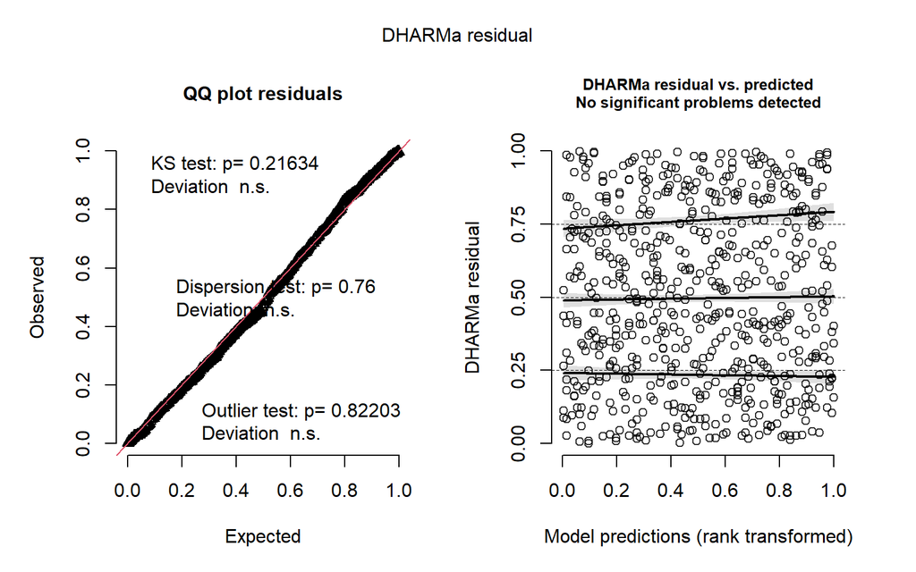

```r
black <- subset(data, data$stim_type == 'Black square')
white <- subset(data, data$stim_type == 'White square')
controls <- rbind(black, white)

pm_f <- glmmTMB(turn~trialn*stimn + (1|subjID), data = controls, family = binomial())

simres <- simulateResiduals(pm_f)
plot(simres)
```

```r
Anova(pm_f)
```

```
## Analysis of Deviance Table (Type II Wald chisquare tests)
##
## Response: turn
##                Chisq Df Pr(>Chisq)
## trialn        0.0231  1     0.8792
## stimn        21.8029  1  3.021e-06 ***
## trialn:stimn  0.2412  1     0.6233
## ---
## Signif. codes:  0 '***' 0.001 '**' 0.01 '*' 0.05 '.' 0.1 ' ' 1
```

```r
et <- emtrends(pm_f, ~trialn, var = 'stimn', type='response')

test(et)
```

```
##  trialn stimn.trend     SE  df z.ratio p.value
##  1          -0.0332 0.0102 Inf  -3.257  0.0011
##  2          -0.0410 0.0121 Inf  -3.401  0.0007
```

No difference between the two trials. However, the probability of responses decreases of around 3% per stimulus

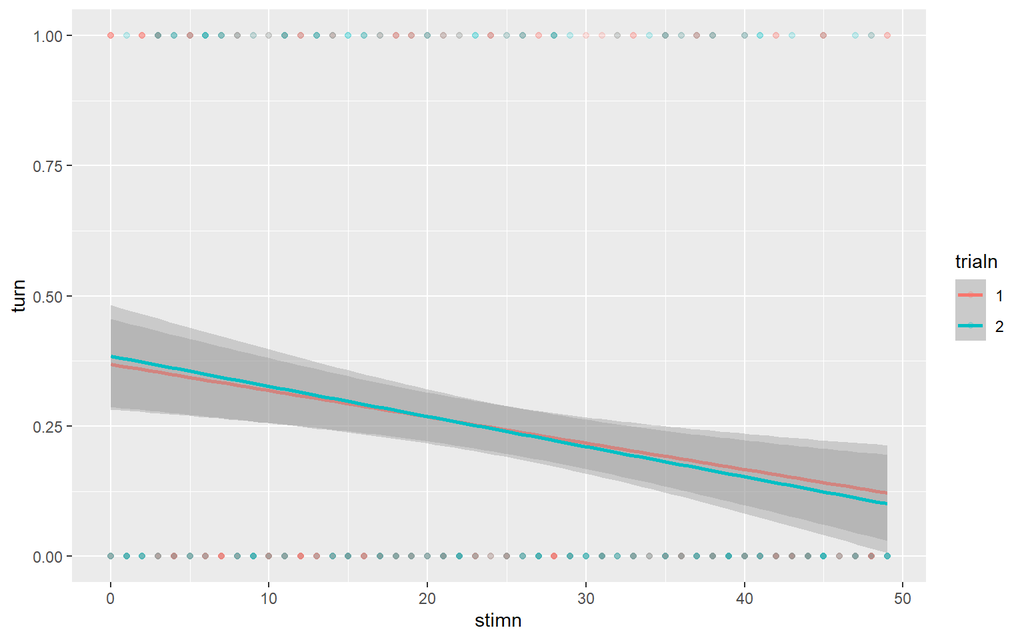

```r
ggplot(controls, aes(x=stimn, y=turn, color=trialn))+
        geom_smooth(method = 'glm')+
        geom_point(alpha=0.2)+
        ylim(0,1)
```

#### 2.1.1.3 Differences between sexes

what about the response rate differences between males, females and juveniles?

```r
pm_s <- glmmTMB(turn~subjSex + (1|subjID), data = controls, family = binomial())

Anova(pm_s)
```

```
## Analysis of Deviance Table (Type II Wald chisquare tests)
##
## Response: turn
##          Chisq Df Pr(>Chisq)
## subjSex 0.8476  2     0.6546
```

```r
e <- emmeans(pm_s, ~subjSex, type='response')
e #just to see
```

```
##  subjSex  prob     SE  df asymp.LCL asymp.UCL
##  F       0.217 0.0597 Inf    0.1220     0.355
##  J       0.183 0.0574 Inf    0.0954     0.322
##  M       0.111 0.0798 Inf    0.0251     0.378
##
## Confidence level used: 0.95
## Intervals are back-transformed from the logit scale
```

```r
pairs(e)
```

```
##  contrast odds.ratio    SE  df null z.ratio p.value
##  F / J          1.24 0.635 Inf    1   0.413  0.9104
##  F / M          2.21 1.940 Inf    1   0.903  0.6382
##  J / M          1.79 1.590 Inf    1   0.652  0.7913
##
## P value adjustment: tukey method for comparing a family of 3 estimates
## Tests are performed on the log odds ratio scale
```

no differences between the sexes

### 2.1.2 Main analysis

Now to the main analysis. How do spiders react to the different stimuli?

Importantly, let’s first select the right subjects!

#### 2.1.2.1 Subjects selection

```r
onlynone <- subset(data, data$stim_type=='none')
mean(onlynone$turn)
```

```
## [1] 0.1283871
```

response to no stimulus is around 10%, equal to basic spider activity. This means that to be considered as responsive, a spider should respond to control stimuli more than to this (we will test it specifically in the analysis, but this is to exclude absolutely unresponsive spiders). I will drop any subject responding <10% of control stimuli. Probably the best option would be to exclude <15%, but let’s see how much we drop.

```r
allsubj <- as.data.frame(tapply(controls$turn, controls$subjID, mean))
colnames(allsubj) <- 'value'

todropsubj <- row.names(subset(allsubj, allsubj$value<=0.1))
tokeepsubj <- row.names(subset(allsubj, allsubj$value>0.1))

selected <- data[ ! data$subjID %in% todropsubj, ]

length(todropsubj)
```

```
## [1] 12
```

```r
length(tokeepsubj)
```

```
## [1] 19
```

This seems a good option

#### 2.1.2.2 Response to stimuli for the active spiders

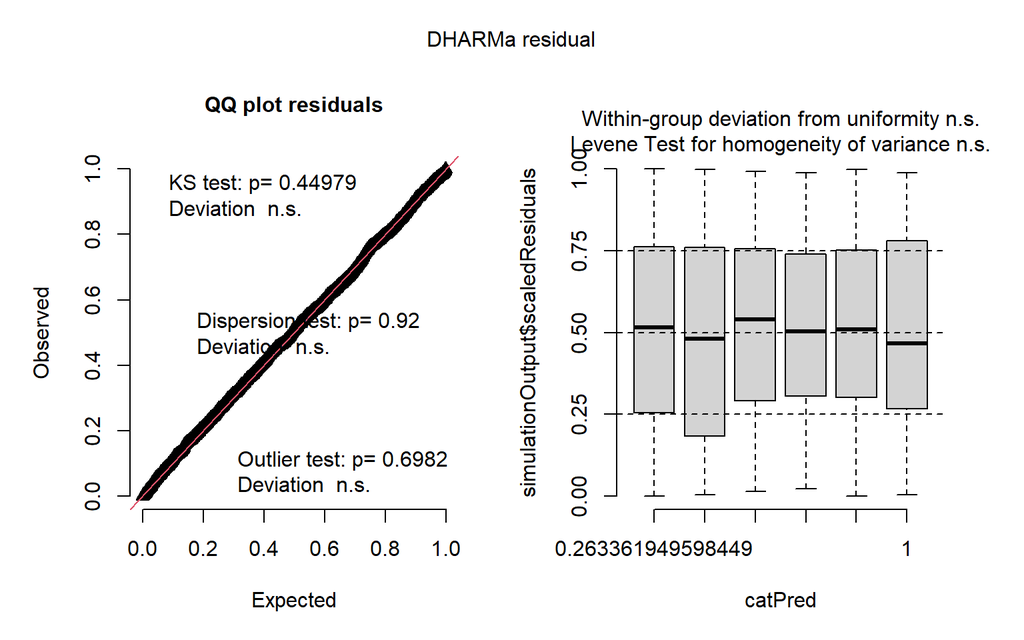

```r
m_m <- glmmTMB(turn~stim_type + (1|subjID), data = selected, family = binomial())

simres <- simulateResiduals(m_m)
plot(simres)
```

```r
Anova(m_m)
```

```
## Analysis of Deviance Table (Type II Wald chisquare tests)
##
## Response: turn
##           Chisq Df Pr(>Chisq)
## stim_type 191.7  5  < 2.2e-16 ***
## ---
## Signif. codes:  0 '***' 0.001 '**' 0.01 '*' 0.05 '.' 0.1 ' ' 1
```

```r
e <- emmeans(m_m, ~stim_type, type='response')
e
```

```
##  stim_type         prob     SE  df asymp.LCL asymp.UCL
##  Black square     0.467 0.0467 Inf     0.378     0.559
##  Grey square      0.423 0.0461 Inf     0.336     0.514
##  none             0.140 0.0178 Inf     0.109     0.179
##  Alternating flip 0.551 0.0465 Inf     0.459     0.639
##  Cryptic          0.334 0.0431 Inf     0.255     0.423
##  White square     0.258 0.0388 Inf     0.189     0.341
##
## Confidence level used: 0.95
## Intervals are back-transformed from the logit scale
```

```r
pairs(e, adjust='bonferroni')
```

```
##  contrast                        odds.ratio     SE  df null z.ratio p.value
##  Black square / Grey square           1.198 0.2550 Inf    1   0.849  1.0000
##  Black square / none                  5.380 0.9510 Inf    1   9.517  <.0001
##  Black square / Alternating flip      0.715 0.1520 Inf    1  -1.582  1.0000
##  Black square / Cryptic               1.747 0.3790 Inf    1   2.570  0.1523
##  Black square / White square          2.522 0.5670 Inf    1   4.110  0.0006
##  Grey square / none                   4.492 0.7980 Inf    1   8.455  <.0001
##  Grey square / Alternating flip       0.597 0.1270 Inf    1  -2.423  0.2310
##  Grey square / Cryptic                1.459 0.3180 Inf    1   1.732  1.0000
##  Grey square / White square           2.105 0.4750 Inf    1   3.297  0.0147
##  none / Alternating flip              0.133 0.0236 Inf    1 -11.364  <.0001
##  none / Cryptic                       0.325 0.0593 Inf    1  -6.162  <.0001
##  none / White square                  0.469 0.0898 Inf    1  -3.957  0.0011
##  Alternating flip / Cryptic           2.443 0.5310 Inf    1   4.107  0.0006
##  Alternating flip / White square      3.526 0.7950 Inf    1   5.588  <.0001
##  Cryptic / White square               1.443 0.3320 Inf    1   1.597  1.0000
##
## P value adjustment: bonferroni method for 15 tests
## Tests are performed on the log odds ratio scale
```

Spiders respond to all stimuli it seems

##### 2.1.2.2.1 Plot

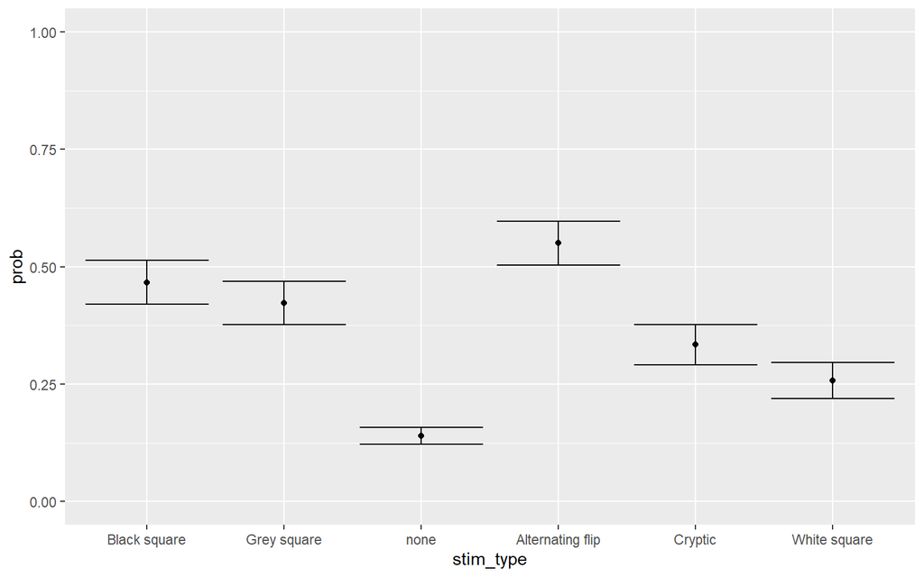

```r
toplot <- as.data.frame(e)

write.csv(toplot, paste0(imagepath, 'exp1_results.csv'))
ggplot(toplot, aes(x=stim_type, y=prob))+
        geom_point() +
        geom_errorbar(aes(ymin=prob-SE, ymax=prob+SE))+
        ylim(0,1)
```

#### 2.1.2.3 For completeness - redo it for all spiders

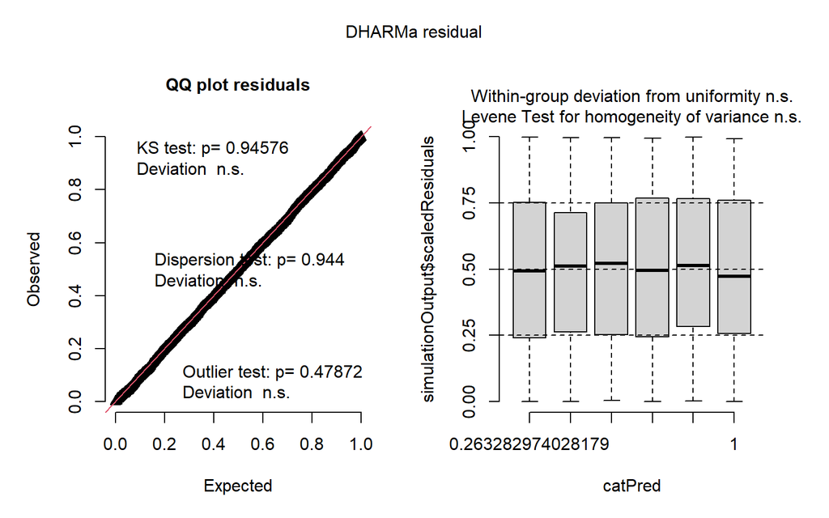

```r
m_mf <- glmmTMB(turn~stim_type + (1|subjID), data = data, family = binomial())

simres <- simulateResiduals(m_mf)
plot(simres)
```

```r
Anova(m_mf)
```

```
## Analysis of Deviance Table (Type II Wald chisquare tests)
##
## Response: turn
##            Chisq Df Pr(>Chisq)
## stim_type 161.38  5  < 2.2e-16 ***
## ---
## Signif. codes:  0 '***' 0.001 '**' 0.01 '*' 0.05 '.' 0.1 ' ' 1
```

```r
e <- emmeans(m_mf, ~stim_type, type='response')
e
```

```
##  stim_type         prob     SE  df asymp.LCL asymp.UCL
##  Black square     0.274 0.0426 Inf    0.1984     0.364
##  Grey square      0.267 0.0420 Inf    0.1928     0.357
##  none             0.100 0.0170 Inf    0.0715     0.139
##  Alternating flip 0.363 0.0486 Inf    0.2738     0.462
##  Cryptic          0.200 0.0354 Inf    0.1396     0.279
##  White square     0.150 0.0293 Inf    0.1014     0.217
##
## Confidence level used: 0.95
## Intervals are back-transformed from the logit scale
```

```r
pairs(e, adjust='bonferroni')
```

```
##  contrast                        odds.ratio     SE  df null z.ratio p.value
##  Black square / Grey square           1.036 0.1940 Inf    1   0.187  1.0000
##  Black square / none                  3.382 0.5220 Inf    1   7.901  <.0001
##  Black square / Alternating flip      0.662 0.1210 Inf    1  -2.263  0.3548
##  Black square / Cryptic               1.505 0.2910 Inf    1   2.111  0.5210
##  Black square / White square          2.130 0.4320 Inf    1   3.729  0.0029
##  Grey square / none                   3.266 0.5050 Inf    1   7.648  <.0001
##  Grey square / Alternating flip       0.639 0.1170 Inf    1  -2.447  0.2159
##  Grey square / Cryptic                1.453 0.2820 Inf    1   1.927  0.8104
##  Grey square / White square           2.057 0.4180 Inf    1   3.549  0.0058
##  none / Alternating flip              0.196 0.0293 Inf    1 -10.879  <.0001
##  none / Cryptic                       0.445 0.0723 Inf    1  -4.986  <.0001
##  none / White square                  0.630 0.1090 Inf    1  -2.674  0.1125
##  Alternating flip / Cryptic           2.274 0.4320 Inf    1   4.325  0.0002
##  Alternating flip / White square      3.218 0.6420 Inf    1   5.861  <.0001
##  Cryptic / White square               1.415 0.2960 Inf    1   1.661  1.0000
##
## P value adjustment: bonferroni method for 15 tests
## Tests are performed on the log odds ratio scale
```

##### 2.1.2.3.1 Plot

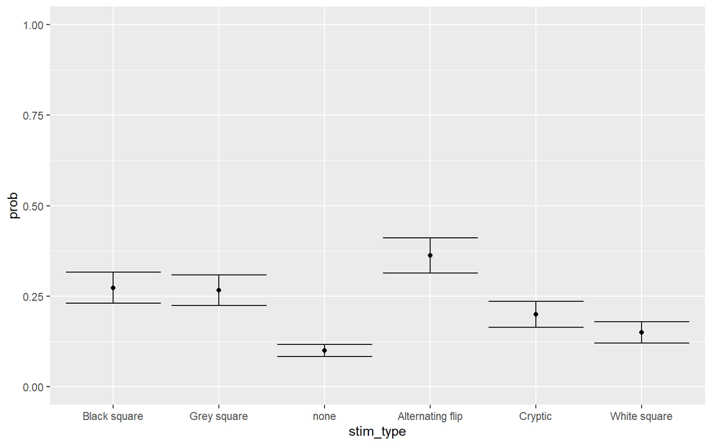

```r
toplot <- as.data.frame(e)
ggplot(toplot, aes(x=stim_type, y=prob))+
        geom_point() +
        geom_errorbar(aes(ymin=prob-SE, ymax=prob+SE))+
        ylim(0,1)
```

## 2.2 Experiment 2

In experiment 2 we included 3 new control stimuli, to check whether the response to refresh stimulus was linked with any luminance change or not

```r
data <- exp2
```

We will follow the same exact procedure as before

### 2.2.1 Preliminary questions

#### 2.2.1.1 Describe subjects

```r
# First, let's count
onerow_per_subj <- subset(data, data$stimn==0)
summary(onerow_per_subj$subjSex)
```

```
##  F  J  M
## 21 15  0
```

we have an almost equal amount of females and juveniles, but almost no males. I am not very sad because males are trash in responding to experiments.

#### 2.2.1.2 Is there an habituation or fatigue effect?

In our experiment, subjects see 50 different stimuli. Moreover, they perform 2 experiments, and so when they undergo this test they may have been tested on the treadmill before. Before doing the main analysis we need to see whether their response decreases over subsequent stimuli and for the two trials.

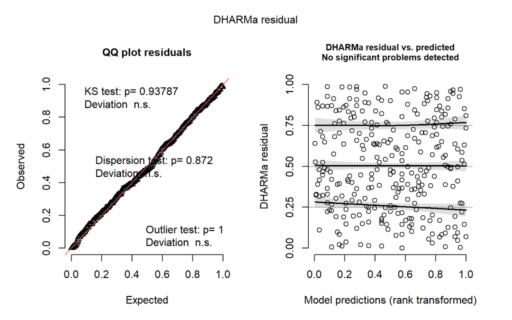

```r
black <- subset(data, data$stim_type == 'Black square')
controls <- black

pm_f <- glmmTMB(turn~trialn*stimn + (1|subjID), data = controls, family = binomial())

simres <- simulateResiduals(pm_f)
plot(simres)
```

```r
Anova(pm_f)
```

```
## Analysis of Deviance Table (Type II Wald chisquare tests)
##
## Response: turn
##               Chisq Df Pr(>Chisq)
## trialn       0.1961  2   0.906610
## stimn        9.0299  1   0.002656 **
## trialn:stimn 0.4048  2   0.816768
## ---
## Signif. codes:  0 '***' 0.001 '**' 0.01 '*' 0.05 '.' 0.1 ' ' 1
```

```r
et <- emtrends(pm_f, ~trialn, var = 'stimn', type='response')

test(et)
```

```
##  trialn stimn.trend     SE  df z.ratio p.value
##  1          -0.0396 0.0151 Inf  -2.621  0.0088
##  2          -0.0277 0.0251 Inf  -1.105  0.2694
##  3          -0.0629 0.0527 Inf  -1.194  0.2325
```

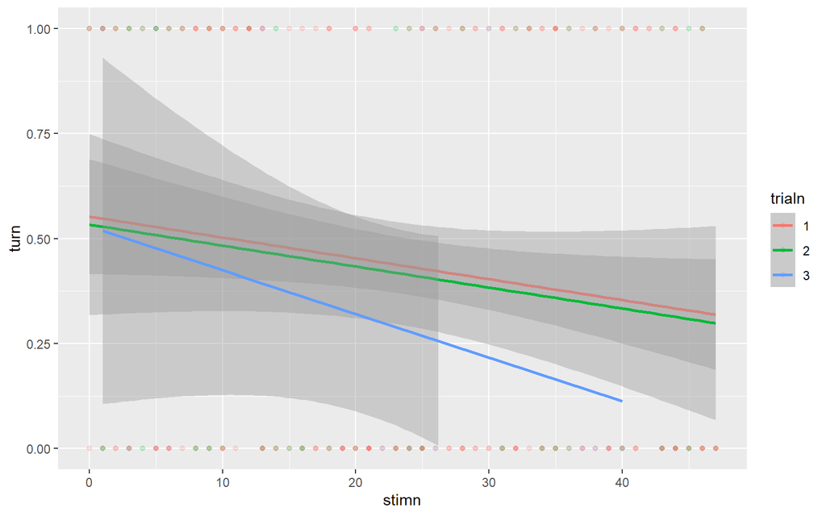

```r
ggplot(controls, aes(x=stimn, y=turn, color=trialn))+
        geom_smooth(method = 'glm')+
        geom_point(alpha=0.2)+
        ylim(0,1)
```

#### 2.2.1.3 Differences between sexes

what about the response rate differences between males, females and juveniles?

```r
pm_s <- glmmTMB(turn~subjSex + (1|subjID), data = controls, family = binomial())

Anova(pm_s)
```

```
## Analysis of Deviance Table (Type II Wald chisquare tests)
##
## Response: turn
##          Chisq Df Pr(>Chisq)
## subjSex 1.0822  1     0.2982
```

```r
e <- emmeans(pm_s, ~subjSex, type='response')
e #just to see
```

```
##  subjSex  prob    SE  df asymp.LCL asymp.UCL
##  F       0.447 0.118 Inf     0.241     0.673
##  J       0.270 0.115 Inf     0.105     0.538
##
## Confidence level used: 0.95
## Intervals are back-transformed from the logit scale
```

```r
pairs(e)
```

```
##  contrast odds.ratio   SE  df null z.ratio p.value
##  F / J          2.19 1.64 Inf    1   1.040  0.2982
##
## Tests are performed on the log odds ratio scale
```

no differences between the sexes

### 2.2.2 Main analysis

Now to the main analysis. How do spiders react to the different stimuli?

Importantly, let’s first select the right subjects!

#### 2.2.2.1 Subjects selection

```r
onlynone <- subset(data, data$stim_type=='none')
mean(onlynone$turn)
```

```
## [1] 0.115162
```

response to no stimulus is around 10%, equal to basic spider activity. This means that to be considered as responsive, a spider should respond to control stimuli more than to this (we will test it specifically in the analysis, but this is to exclude absolutely unresponsive spiders). I will drop any subject responding <10% of control stimuli. Probably the best option would be to exclude <15%, but let’s see how much we drop.

```r
allsubj <- as.data.frame(tapply(controls$turn, controls$subjID, mean))
colnames(allsubj) <- 'value'

todropsubj <- row.names(subset(allsubj, allsubj$value<=0.1))
tokeepsubj <- row.names(subset(allsubj, allsubj$value>0.1))

selected <- data[ ! data$subjID %in% todropsubj, ]

length(todropsubj)
```

```
## [1] 7
```

```r
length(tokeepsubj)
```

```
## [1] 29
```

#### 2.2.2.2 Response to stimuli for the active spiders

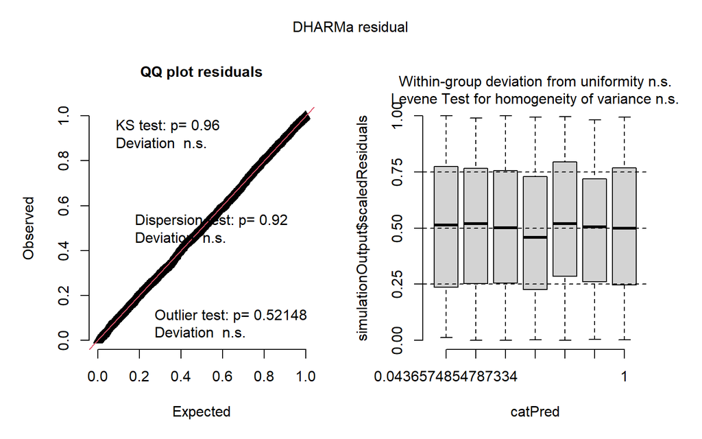

```r
m_m <- glmmTMB(turn~stim_type + (1|subjID), data = selected, family = binomial())

simres <- simulateResiduals(m_m)
plot(simres)
```

```r
Anova(m_m)
```

```
## Analysis of Deviance Table (Type II Wald chisquare tests)
##
## Response: turn
##            Chisq Df Pr(>Chisq)
## stim_type 393.53  6  < 2.2e-16 ***
## ---
## Signif. codes:  0 '***' 0.001 '**' 0.01 '*' 0.05 '.' 0.1 ' ' 1
```

```r
e <- emmeans(m_m, ~stim_type, type='response')
e
```

```
##  stim_type          prob     SE  df asymp.LCL asymp.UCL
##  Black square     0.5246 0.0511 Inf    0.4248     0.623
##  none             0.1093 0.0168 Inf    0.0805     0.147
##  Alternating flip 0.5148 0.0512 Inf    0.4152     0.613
##  Random flash     0.0883 0.0213 Inf    0.0545     0.140
##  Cryptic          0.4606 0.0509 Inf    0.3637     0.561
##  Black flash      0.0624 0.0171 Inf    0.0361     0.106
##  White flash      0.1191 0.0258 Inf    0.0770     0.180
##
## Confidence level used: 0.95
## Intervals are back-transformed from the logit scale
```

```r
pairs(e, adjust='bonferroni')
```

```
##  contrast                        odds.ratio     SE  df null z.ratio p.value
##  Black square / none                  8.991 1.4900 Inf    1  13.285  <.0001
##  Black square / Alternating flip      1.040 0.2070 Inf    1   0.199  1.0000
##  Black square / Random flash         11.394 2.9600 Inf    1   9.355  <.0001
##  Black square / Cryptic               1.292 0.2570 Inf    1   1.290  1.0000
##  Black square / Black flash          16.591 4.7800 Inf    1   9.741  <.0001
##  Black square / White flash           8.165 1.9700 Inf    1   8.717  <.0001
##  none / Alternating flip              0.116 0.0191 Inf    1 -13.066  <.0001
##  none / Random flash                  1.267 0.2930 Inf    1   1.024  1.0000
##  none / Cryptic                       0.144 0.0236 Inf    1 -11.809  <.0001
##  none / Black flash                   1.845 0.4840 Inf    1   2.335  0.4108
##  none / White flash                   0.908 0.1900 Inf    1  -0.459  1.0000
##  Alternating flip / Random flash     10.951 2.8500 Inf    1   9.209  <.0001
##  Alternating flip / Cryptic           1.242 0.2470 Inf    1   1.091  1.0000
##  Alternating flip / Black flash      15.947 4.6000 Inf    1   9.609  <.0001
##  Alternating flip / White flash       7.848 1.8900 Inf    1   8.559  <.0001
##  Random flash / Cryptic               0.113 0.0294 Inf    1  -8.391  <.0001
##  Random flash / Black flash           1.456 0.4810 Inf    1   1.138  1.0000
##  Random flash / White flash           0.717 0.2080 Inf    1  -1.148  1.0000
##  Cryptic / Black flash               12.837 3.6900 Inf    1   8.871  <.0001
##  Cryptic / White flash                6.317 1.5200 Inf    1   7.675  <.0001
##  Black flash / White flash            0.492 0.1550 Inf    1  -2.247  0.5180
##
## P value adjustment: bonferroni method for 21 tests
## Tests are performed on the log odds ratio scale
```

##### 2.2.2.2.1 Plot

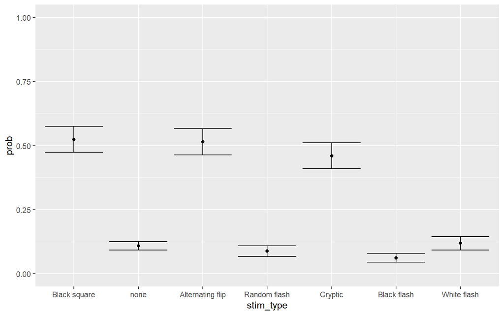

```r
toplot <- as.data.frame(e)
write.csv(toplot, paste0(imagepath, 'exp2_results.csv'))

ggplot(toplot, aes(x=stim_type, y=prob))+
        geom_point() +
        geom_errorbar(aes(ymin=prob-SE, ymax=prob+SE))+
        ylim(0,1)
```

#### 2.2.2.3 For completeness - redo it for all spiders

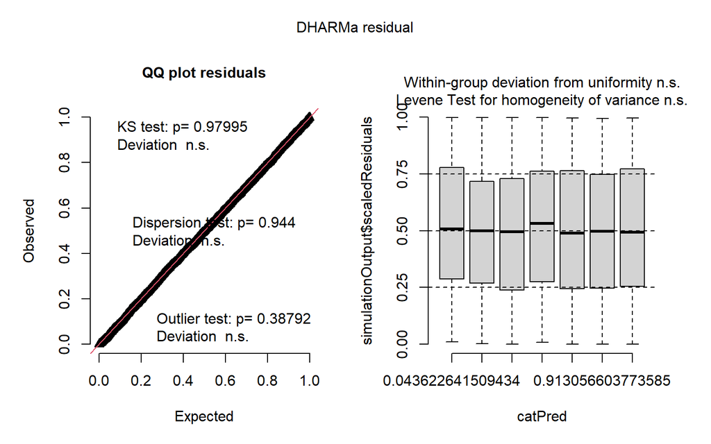

```r
m_mf <- glmmTMB(turn~stim_type + (1|subjID), data = data, family = binomial())

simres <- simulateResiduals(m_mf)
plot(simres)
```

```r
Anova(m_mf)
```

```
## Analysis of Deviance Table (Type II Wald chisquare tests)
##
## Response: turn
##            Chisq Df Pr(>Chisq)
## stim_type 384.89  6  < 2.2e-16 ***
## ---
## Signif. codes:  0 '***' 0.001 '**' 0.01 '*' 0.05 '.' 0.1 ' ' 1
```

```r
e <- emmeans(m_mf, ~stim_type, type='response')
e
```

```
##  stim_type          prob     SE  df asymp.LCL asymp.UCL
##  Black square     0.3947 0.0534 Inf    0.2961    0.5026
##  none             0.0830 0.0152 Inf    0.0576    0.1181
##  Alternating flip 0.4239 0.0545 Inf    0.3221    0.5326
##  Random flash     0.0635 0.0167 Inf    0.0376    0.1052
##  Cryptic          0.3619 0.0518 Inf    0.2676    0.4682
##  Black flash      0.0582 0.0157 Inf    0.0340    0.0978
##  White flash      0.0937 0.0221 Inf    0.0585    0.1468
##
## Confidence level used: 0.95
## Intervals are back-transformed from the logit scale
```

```r
pairs(e, adjust='bonferroni')
```

```
##  contrast                        odds.ratio     SE  df null z.ratio p.value
##  Black square / none                  7.209 1.1200 Inf    1  12.719  <.0001
##  Black square / Alternating flip      0.886 0.1650 Inf    1  -0.650  1.0000
##  Black square / Random flash          9.622 2.4100 Inf    1   9.031  <.0001
##  Black square / Cryptic               1.150 0.2150 Inf    1   0.747  1.0000
##  Black square / Black flash          10.555 2.7100 Inf    1   9.170  <.0001
##  Black square / White flash           6.305 1.4300 Inf    1   8.116  <.0001
##  none / Alternating flip              0.123 0.0191 Inf    1 -13.490  <.0001
##  none / Random flash                  1.335 0.3010 Inf    1   1.281  1.0000
##  none / Cryptic                       0.159 0.0248 Inf    1 -11.800  <.0001
##  none / Black flash                   1.464 0.3400 Inf    1   1.641  1.0000
##  none / White flash                   0.875 0.1740 Inf    1  -0.674  1.0000
##  Alternating flip / Random flash     10.859 2.7200 Inf    1   9.511  <.0001
##  Alternating flip / Cryptic           1.297 0.2420 Inf    1   1.396  1.0000
##  Alternating flip / Black flash      11.911 3.0600 Inf    1   9.638  <.0001
##  Alternating flip / White flash       7.115 1.6100 Inf    1   8.647  <.0001
##  Random flash / Cryptic               0.119 0.0300 Inf    1  -8.470  <.0001
##  Random flash / Black flash           1.097 0.3340 Inf    1   0.304  1.0000
##  Random flash / White flash           0.655 0.1830 Inf    1  -1.512  1.0000
##  Cryptic / Black flash                9.181 2.3600 Inf    1   8.622  <.0001
##  Cryptic / White flash                5.484 1.2500 Inf    1   7.495  <.0001
##  Black flash / White flash            0.597 0.1700 Inf    1  -1.806  1.0000
##
## P value adjustment: bonferroni method for 21 tests
## Tests are performed on the log odds ratio scale
```

again, same

##### 2.2.2.3.1 Plot

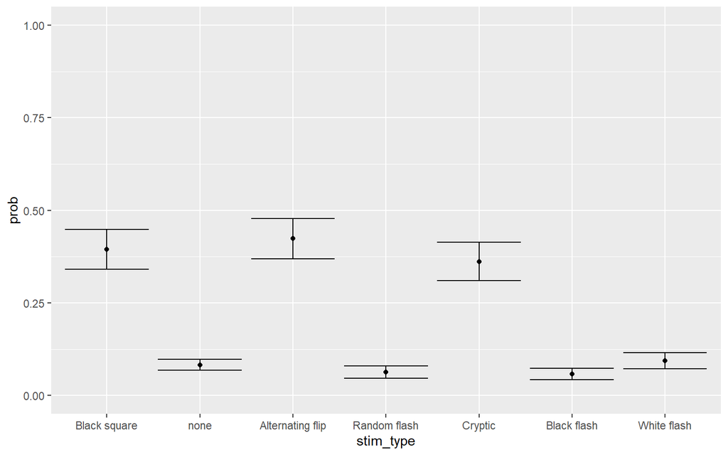

```r
toplot <- as.data.frame(e)
ggplot(toplot, aes(x=stim_type, y=prob))+
        geom_point() +
        geom_errorbar(aes(ymin=prob-SE, ymax=prob+SE))+
        ylim(0,1)
```

## 2.3 Experiment 3

```r
data <- exp3
```

### 2.3.1 Preliminary questions

#### 2.3.1.1 Describe subjects

```r
# First, let's count
onerow_per_subj <- subset(data, data$stimn==0)
summary(onerow_per_subj$subjSex)
```

```
##  F  J  M
## 19  9  5
```

#### 2.3.1.2 Is there an habituation or fatigue effect?

In our experiment, subjects see 50 different stimuli. Moreover, they perform 2 experiments, and so when they undergo this test they may have been tested on the treadmill before. Before doing the main analysis we need to see whether their response decreases over subsequent stimuli and for the two trials.

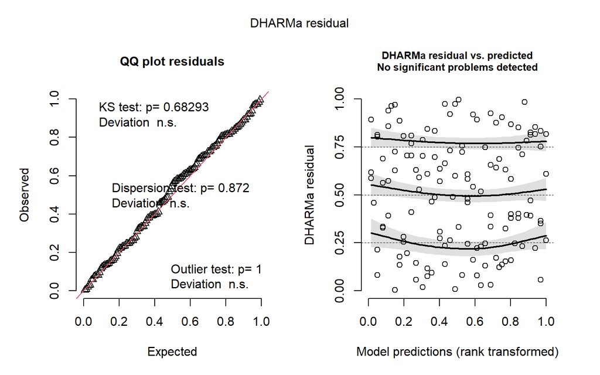

```r
black <- subset(data, data$stim_type == 'Black square')
black <- subset(black, black$eye == 'ALE')
controls <- black

pm_f <- glmmTMB(turn~stimn + (1|subjID), data = controls, family = binomial())

simres <- simulateResiduals(pm_f)
plot(simres)
```

```r
Anova(pm_f)
```

```
## Analysis of Deviance Table (Type II Wald chisquare tests)
##
## Response: turn
##        Chisq Df Pr(>Chisq)
## stimn 1.6857  1     0.1942
```

```r
et <- emtrends(pm_f, ~1, var = 'stimn', type='response')

test(et)
```

```
##  1       stimn.trend     SE  df z.ratio p.value
##  overall     -0.0213 0.0164 Inf  -1.298  0.1942
```

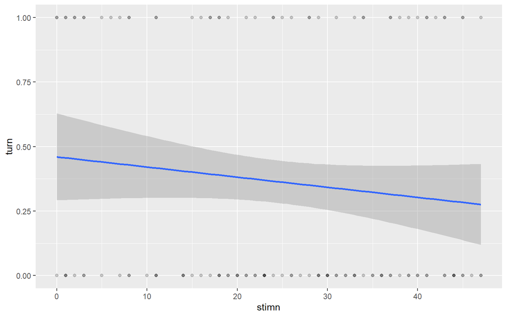

```r
ggplot(controls, aes(x=stimn, y=turn))+
        geom_smooth(method = 'glm')+
        geom_point(alpha=0.2)+
        ylim(0,1)
```

#### 2.3.1.3 Differences between sexes

what about the response rate differences between males, females and juveniles?

```r
pm_s <- glmmTMB(turn~subjSex + (1|subjID), data = controls, family = binomial())

Anova(pm_s)
```

```
## Analysis of Deviance Table (Type II Wald chisquare tests)
##
## Response: turn
##          Chisq Df Pr(>Chisq)
## subjSex 7.8924  2    0.01933 *
## ---
## Signif. codes:  0 '***' 0.001 '**' 0.01 '*' 0.05 '.' 0.1 ' ' 1
```

```r
e <- emmeans(pm_s, ~subjSex, type='response')
e #just to see
```

```
##  subjSex  prob     SE  df asymp.LCL asymp.UCL
##  F       0.483 0.0823 Inf    0.3282     0.640
##  J       0.131 0.0696 Inf    0.0433     0.333
##  M       0.216 0.1200 Inf    0.0642     0.525
##
## Confidence level used: 0.95
## Intervals are back-transformed from the logit scale
```

```r
pairs(e)
```

```
##  contrast odds.ratio    SE  df null z.ratio p.value
##  F / J         6.202 4.290 Inf    1   2.641  0.0225
##  F / M         3.388 2.640 Inf    1   1.566  0.2605
##  J / M         0.546 0.496 Inf    1  -0.666  0.7832
##
## P value adjustment: tukey method for comparing a family of 3 estimates
## Tests are performed on the log odds ratio scale
```

Juveniles here respond much less. Is strange because it is the first time, but percentages are similar to other experiments.

### 2.3.2 Main analysis

Now to the main analysis. How do spiders react to the different stimuli?

Importantly, let’s first select the right subjects!

#### 2.3.2.1 Subjects selection

```r
black <- subset(data, data$stim_type == 'Black square')
controls <- black

onlynone <- subset(data, data$stim_type=='none')
mean(onlynone$turn)
```

```
## [1] 0.08459596
```

response to no stimulus is around 10%, equal to basic spider activity. This means that to be considered as responsive, a spider should respond to control stimuli more than to this (we will test it specifically in the analysis, but this is to exclude absolutely unresponsive spiders). I will drop any subject responding <10% of control stimuli. Probably the best option would be to exclude <15%, but let’s see how much we drop.

```r
allsubj <- as.data.frame(tapply(controls$turn, controls$subjID, mean))
colnames(allsubj) <- 'value'

todropsubj <- row.names(subset(allsubj, allsubj$value<=0.1))
tokeepsubj <- row.names(subset(allsubj, allsubj$value>0.1))

selected <- data[ ! data$subjID %in% todropsubj, ]

length(todropsubj)
```

```
## [1] 11
```

```r
length(tokeepsubj)
```

```
## [1] 22
```

#### 2.3.2.2 Response to stimuli for the active spiders

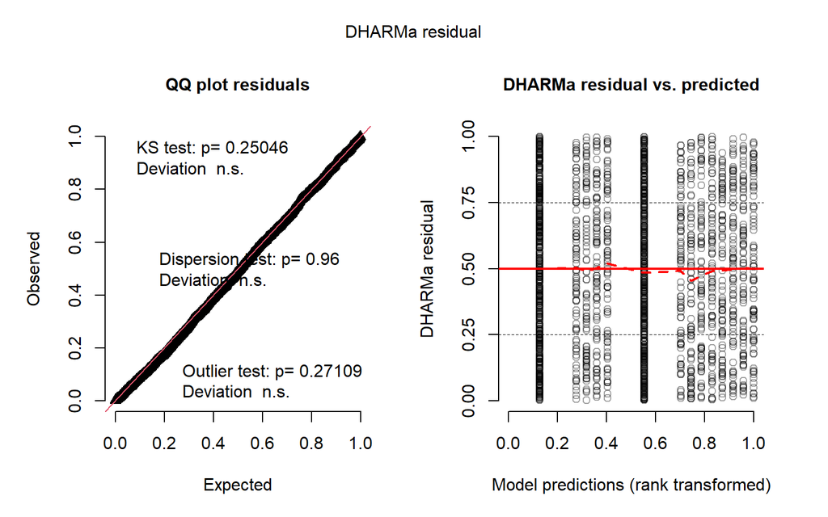

```r
m_m <- glmmTMB(turn~stim_type*eye + (1|subjID), data = selected, family = binomial())

simres <- simulateResiduals(m_m)
plot(simres)
```

```r
Anova(m_m)
```

```
## Analysis of Deviance Table (Type II Wald chisquare tests)
##
## Response: turn
##                 Chisq Df Pr(>Chisq)
## stim_type     152.141  6  < 2.2e-16 ***
## eye            35.239  1  2.917e-09 ***
## stim_type:eye  16.518  6    0.01123 *
## ---
## Signif. codes:  0 '***' 0.001 '**' 0.01 '*' 0.05 '.' 0.1 ' ' 1
```

```r
e <- emmeans(m_m, ~stim_type*eye, type='response')
e
```

```
##  stim_type        eye   prob     SE  df asymp.LCL asymp.UCL
##  Black square     ALE 0.5489 0.0663 Inf    0.4185     0.673
##  none             ALE 0.1126 0.0199 Inf    0.0791     0.158
##  Alternating flip ALE 0.5740 0.0658 Inf    0.4430     0.695
##  Random flash     ALE 0.1403 0.0403 Inf    0.0782     0.239
##  Cryptic          ALE 0.3004 0.0589 Inf    0.1988     0.426
##  Black flash      ALE 0.0979 0.0330 Inf    0.0496     0.184
##  White flash      ALE 0.1403 0.0403 Inf    0.0782     0.239
##  Black square     PLE 0.2413 0.0534 Inf    0.1523     0.360
##  none             PLE 0.0712 0.0145 Inf    0.0475     0.105
##  Alternating flip PLE 0.1843 0.0466 Inf    0.1095     0.293
##  Random flash     PLE 0.1084 0.0349 Inf    0.0565     0.198
##  Cryptic          PLE 0.1731 0.0451 Inf    0.1014     0.280
##  Black flash      PLE 0.0979 0.0330 Inf    0.0496     0.184
##  White flash      PLE 0.0876 0.0310 Inf    0.0430     0.170
##
## Confidence level used: 0.95
## Intervals are back-transformed from the logit scale
```

```r
contrast_vs_none <- function(e, ctrl = "none") {
  g   <- as.data.frame(e)
  idx <- function(st, ey) as.numeric(g$stim_type == st & g$eye == ey)
  cl  <- list()
  for (s in setdiff(levels(droplevels(g$stim_type)), ctrl)) {
    cl[[paste(s, "ALE vs none")]] <- idx(s, "ALE") - idx(ctrl, "ALE")
    cl[[paste(s, "PLE vs none")]] <- idx(s, "PLE") - idx(ctrl, "PLE")
    cl[[paste(s, "ALE vs PLE")]]  <- idx(s, "ALE") - idx(s,    "PLE")
  }
  contrast(e, cl, adjust = "bonferroni")
}

contrast_vs_none(e)
```

```
##  contrast                     odds.ratio    SE  df null z.ratio p.value
##  Black square ALE vs none          9.585 2.530 Inf    1   8.564  <.0001
##  Black square PLE vs none          4.147 1.240 Inf    1   4.756  <.0001
##  Black square ALE vs PLE           3.825 1.300 Inf    1   3.955  0.0014
##  Alternating flip ALE vs none     10.616 2.820 Inf    1   8.907  <.0001
##  Alternating flip PLE vs none      2.945 0.932 Inf    1   3.411  0.0117
##  Alternating flip ALE vs PLE       5.966 2.120 Inf    1   5.014  <.0001
##  Random flash ALE vs none          1.285 0.420 Inf    1   0.767  1.0000
##  Random flash PLE vs none          1.584 0.580 Inf    1   1.256  1.0000
##  Random flash ALE vs PLE           1.343 0.597 Inf    1   0.662  1.0000
##  Cryptic ALE vs none               3.383 0.925 Inf    1   4.456  0.0002
##  Cryptic PLE vs none               2.729 0.877 Inf    1   3.124  0.0321
##  Cryptic ALE vs PLE                2.051 0.753 Inf    1   1.958  0.9050
##  Black flash ALE vs none           0.855 0.314 Inf    1  -0.426  1.0000
##  Black flash PLE vs none           1.415 0.535 Inf    1   0.918  1.0000
##  Black flash ALE vs PLE            1.000 0.485 Inf    1   0.000  1.0000
##  White flash ALE vs none           1.285 0.420 Inf    1   0.767  1.0000
##  White flash PLE vs none           1.252 0.491 Inf    1   0.572  1.0000
##  White flash ALE vs PLE            1.699 0.793 Inf    1   1.136  1.0000
##
## P value adjustment: bonferroni method for 18 tests
## Tests are performed on the log odds ratio scale
```

##### 2.3.2.2.1 Plot

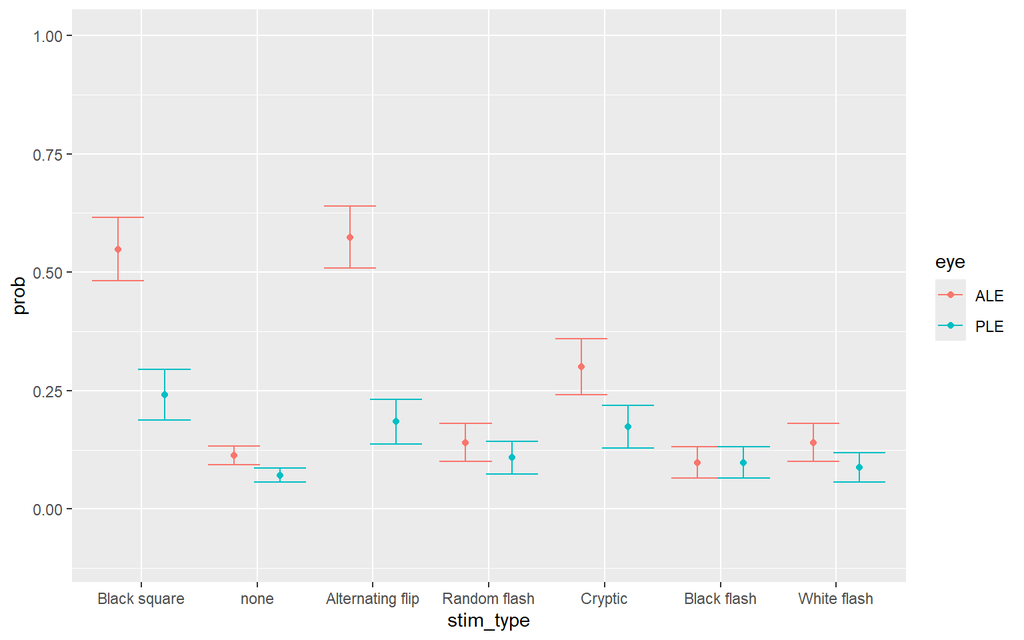

```r
toplot <- as.data.frame(e)
write.csv(toplot, paste0(imagepath, 'exp3_results.csv'))

ggplot(toplot, aes(x=stim_type, y=prob, color=eye))+
        geom_point(position = position_dodge(0.8)) +
        geom_errorbar(aes(ymin=prob-SE, ymax=prob+SE),position = position_dodge(0.8))+
        ylim(-0.1,1)
```

#### 2.3.2.3 For completeness - redo it for all spiders

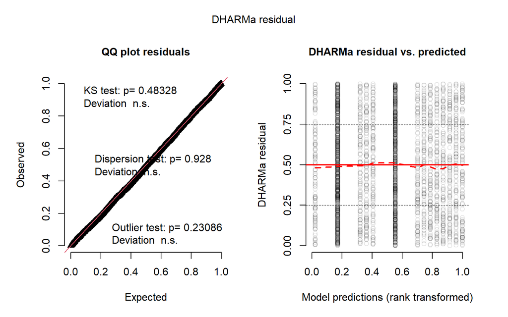

```r
m_mf <- glmmTMB(turn~stim_type*eye + (1|subjID), data = data, family = binomial())

simres <- simulateResiduals(m_mf)
plot(simres)
```

```r
Anova(m_mf)
```

```
## Analysis of Deviance Table (Type II Wald chisquare tests)
##
## Response: turn
##                 Chisq Df Pr(>Chisq)
## stim_type     144.926  6  < 2.2e-16 ***
## eye            34.933  1  3.412e-09 ***
## stim_type:eye  16.837  6     0.0099 **
## ---
## Signif. codes:  0 '***' 0.001 '**' 0.01 '*' 0.05 '.' 0.1 ' ' 1
```

```r
e <- emmeans(m_mf, ~stim_type*eye, type='response')
e
```

```
##  stim_type        eye   prob     SE  df asymp.LCL asymp.UCL
##  Black square     ALE 0.3192 0.0634 Inf    0.2092    0.4537
##  none             ALE 0.0651 0.0152 Inf    0.0410    0.1020
##  Alternating flip ALE 0.3931 0.0688 Inf    0.2689    0.5327
##  Random flash     ALE 0.0695 0.0237 Inf    0.0352    0.1327
##  Cryptic          ALE 0.1583 0.0418 Inf    0.0923    0.2581
##  Black flash      ALE 0.0530 0.0197 Inf    0.0253    0.1076
##  White flash      ALE 0.0752 0.0250 Inf    0.0386    0.1412
##  Black square     PLE 0.1243 0.0355 Inf    0.0697    0.2118
##  none             PLE 0.0429 0.0107 Inf    0.0261    0.0696
##  Alternating flip PLE 0.1051 0.0316 Inf    0.0573    0.1848
##  Random flash     PLE 0.0530 0.0197 Inf    0.0253    0.1076
##  Cryptic          PLE 0.0868 0.0276 Inf    0.0458    0.1584
##  Black flash      PLE 0.0530 0.0197 Inf    0.0253    0.1076
##  White flash      PLE 0.0425 0.0170 Inf    0.0193    0.0913
##
## Confidence level used: 0.95
## Intervals are back-transformed from the logit scale
```

```r
contrast_vs_none <- function(e, ctrl = "none") {
  g   <- as.data.frame(e)
  idx <- function(st, ey) as.numeric(g$stim_type == st & g$eye == ey)
  cl  <- list()
  for (s in setdiff(levels(droplevels(g$stim_type)), ctrl)) {
    cl[[paste(s, "ALE vs none")]] <- idx(s, "ALE") - idx(ctrl, "ALE")
    cl[[paste(s, "PLE vs none")]] <- idx(s, "PLE") - idx(ctrl, "PLE")
    cl[[paste(s, "ALE vs PLE")]]  <- idx(s, "ALE") - idx(s,    "PLE")
  }
  contrast(e, cl, adjust = "bonferroni")
}

contrast_vs_none(e)
```

```
##  contrast                     odds.ratio    SE  df null z.ratio p.value
##  Black square ALE vs none          6.727 1.610 Inf    1   7.954  <.0001
##  Black square PLE vs none          3.166 0.904 Inf    1   4.037  0.0010
##  Black square ALE vs PLE           3.303 1.050 Inf    1   3.743  0.0033
##  Alternating flip ALE vs none      9.293 2.210 Inf    1   9.359  <.0001
##  Alternating flip PLE vs none      2.620 0.776 Inf    1   3.254  0.0205
##  Alternating flip ALE vs PLE       5.515 1.810 Inf    1   5.208  <.0001
##  Random flash ALE vs none          1.071 0.343 Inf    1   0.216  1.0000
##  Random flash PLE vs none          1.249 0.446 Inf    1   0.623  1.0000
##  Random flash ALE vs PLE           1.334 0.587 Inf    1   0.655  1.0000
##  Cryptic ALE vs none               2.699 0.705 Inf    1   3.798  0.0026
##  Cryptic PLE vs none               2.122 0.658 Inf    1   2.427  0.2744
##  Cryptic ALE vs PLE                1.978 0.707 Inf    1   1.907  1.0000
##  Black flash ALE vs none           0.803 0.280 Inf    1  -0.628  1.0000
##  Black flash PLE vs none           1.249 0.446 Inf    1   0.623  1.0000
##  Black flash ALE vs PLE            1.000 0.461 Inf    1   0.000  1.0000
##  White flash ALE vs none           1.166 0.364 Inf    1   0.492  1.0000
##  White flash PLE vs none           0.991 0.381 Inf    1  -0.023  1.0000
##  White flash ALE vs PLE            1.830 0.836 Inf    1   1.322  1.0000
##
## P value adjustment: bonferroni method for 18 tests
## Tests are performed on the log odds ratio scale
```

##### 2.3.2.3.1 Plot

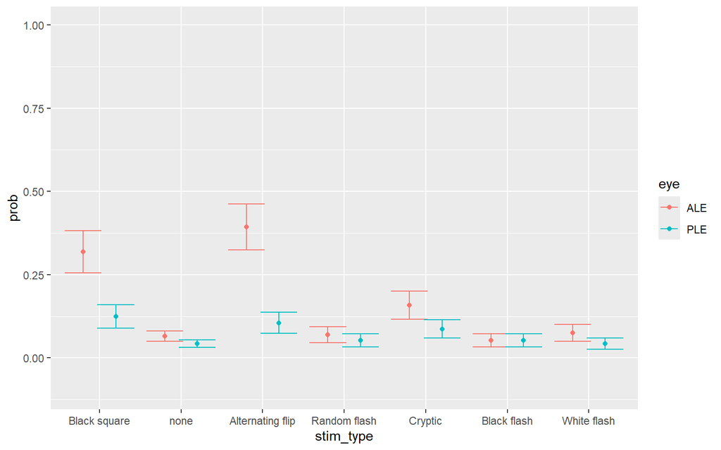

```r
toplot <- as.data.frame(e)
ggplot(toplot, aes(x=stim_type, y=prob, color=eye))+
        geom_point(position = position_dodge(0.8)) +
        geom_errorbar(aes(ymin=prob-SE, ymax=prob+SE),position = position_dodge(0.8))+
        ylim(-0.1,1)
```